# Análisis y Modelado Analítico de Transacciones de Supermercado

Mercury Application

This output won't appear in the web app.

## Descripción de los datos.

Este dataset contiene información sobre transacciones de retail, incluyendo productos, categorías y transacciones de clientes en múltiples tiendas. Los datos están distribuidos en tres tipos de archivos CSV que se relacionan entre sí mediante identificadores comunes.

## Estructura de Archivos

### 1. **Categories.csv**

**Ubicación:** `Products/Categories.csv`

**Descripción:** Catálogo maestro de categorías de productos.

**Formato:**

- **Separador:** `|` (pipe)
- **Encabezado:** No incluye encabezados

**Columnas:**

| Columna | Tipo de Dato | Descripción |
| --- | --- | --- |
| `category_id` | int64 | Identificador único de la categoría |
| `category_name` | object (string) | Nombre descriptivo de la categoría |

**Características:**

- Clave primaria: `category_id`
- Sin valores faltantes esperados
- Sin duplicados esperados

**Ejemplo de estructura:**

```
1|Electrónica
2|Alimentos
3|Ropa
```

### 2. **ProductCategory.csv**

**Ubicación:** `Products/ProductCategory.csv`

**Descripción:** Tabla de relación entre productos y sus categorías.

**Formato:**

- **Separador:** `|` (pipe)
- **Encabezado:** Sí incluye encabezados

**Columnas:**

| Columna | Tipo de Dato | Descripción |
| --- | --- | --- |
| `v.Code_pr` | int64 | Código/ID único del producto |
| `v.code` | int64 | Código de categoría (FK a Categories.category_id) |

**Características:**

- Relación: Muchos a uno (varios productos → una categoría)
- Posibles valores faltantes en casos de productos sin categorizar
- Posibles duplicados si un producto tiene múltiples categorías (verificar en datos)

**Ejemplo de estructura:**

```
v.Code_pr|v.code
10001|1
10002|1
10003|2
```

### 3. **Archivos de Transacciones**

**Ubicación:** `Transactions/*_Tran.csv`

**Descripción:** Registros de transacciones de clientes. Existen múltiples archivos que se concatenan para formar el dataset completo.

**Formato:**

- **Separador:** `|` (pipe)
- **Encabezado:** No incluye encabezados
- **Patrón de archivos:** `*_Tran.csv` (ej: `Store1_Tran.csv`, `Store2_Tran.csv`)

**Columnas:**

| Columna | Tipo de Dato (original) | Tipo de Dato (procesado) | Descripción |
| --- | --- | --- | --- |
| `date` | object (string) | datetime64[ns] | Fecha y hora de la transacción |
| `store_id` | int64 | int64 | Identificador de la tienda donde ocurrió la transacción |
| `customer_id` | int64 | int64 | Identificador único del cliente |
| `products` | object (string) | object (tuple) | Lista de IDs de productos comprados, separados por espacios |

**Columnas Derivadas:**

| Columna | Tipo de Dato | Descripción |
| --- | --- | --- |
| `num_products` | int64 | Cantidad de productos distintos en la transacción |

**Características:**

## Metodología de análisis

## 1. Carga y Preparación de Datos

### 1.1 Importación de Datos

- **Categorías**: Archivo `Categories.csv` con separador `|` sin encabezados
- **Productos-Categorías**: Archivo `ProductCategory.csv` con separador `|` con encabezados
- **Transacciones**: Múltiples archivos `*_Tran.csv` concatenados en un único dataset

### 1.2 Transformaciones Iniciales

- Conversión del campo `date` a formato datetime
- Separación del campo `products` (string) a listas de IDs
- Conversión de listas a tuplas para permitir operaciones de conjunto
- Cálculo de la variable derivada `num_products` (cantidad de productos por transacción)

### 1.3 Expansión y Enriquecimiento

- **Explosión de productos**: Cada transacción se descompone en filas individuales (un producto por fila)
- **Joins relacionales**:
  - `exploded_products` ⟷ `ProductCategory` (por `product_id`)
  - Resultado ⟷ `Categories` (por `category_id`)
- Resultado final: dataset con información completa de producto, categoría y transacción

## 2. Análisis Descriptivo

### 2.1 Métricas Clave

Cálculo de indicadores fundamentales:

- Total de unidades vendidas
- Número total de transacciones
- Clientes únicos
- Productos únicos

### 2.2 Análisis de Top Rankings

- **Top 10 productos más vendidos**: Conteo de frecuencias de `product_id`
- **Top 10 clientes**: Conteo de transacciones por `customer_id`
- **Top 10 categorías**: Agregación por `category_name`

### 2.3 Visualizaciones Base

- Gráficos de barras horizontales para rankings
- Series de tiempo con agregaciones diarias, semanales y mensuales
- Identificación de picos mediante `scipy.signal.find_peaks`

## 3. Análisis Temporal

### 3.1 Agregaciones Temporales

- **Ventas por día**: Resample diario con suma de `num_products`
- **Ventas por semana**: Agrupación por período semanal
- **Ventas por mes**: Agrupación por período mensual

### 3.2 Detección de Patrones

- Identificación de días con mayor volumen de ventas
- Análisis de ventas por día de la semana
- Análisis de ventas por hora del día (limitado por granularidad de datos)

### 3.3 Tendencias y Suavizado

- Cálculo de medias móviles de 7 y 30 días
- Visualización de tendencias a mediano plazo
- Detección de estacionalidad

## 4. Análisis por Cliente

### 4.1 Variables de Comportamiento

Cálculo de métricas por cliente:

- `total_compras`: Conteo de transacciones
- `primera_compra` y `ultima_compra`: Rango temporal de actividad
- `total_productos`: Suma de productos comprados
- `tiendas_visitadas`: Número de tiendas únicas
- `dias_entre_compras`: Promedio de días entre transacciones consecutivas
- `recencia`: Días desde la última compra
- `antiguedad_dias`: Tiempo total como cliente activo
- `ticket_promedio`: Promedio de productos por transacción

### 4.2 Segmentación Descriptiva

- **Por frecuencia**: Clasificación en Ocasional, Moderado, Frecuente, Muy Frecuente
- **Por intervalo**: Clasificación según regularidad de compra
- Visualización mediante gráficos de barras

### 4.3 Análisis de Distribuciones

- Histogramas de frecuencia de compra
- Histogramas de intervalo entre compras
- Boxplots para detectar outliers

## 5. Análisis de Correlación

### 5.1 Matriz de Correlación

Análisis de relaciones entre variables de comportamiento del cliente:

- Frecuencia vs Volumen total
- Frecuencia vs Productos distintos
- Diversidad de categorías vs Productos distintos
- Recencia vs Antigüedad

### 5.2 Heatmap de Correlaciones

Visualización mediante `seaborn.heatmap` con:

- Anotaciones de valores
- Escala de color divergente (coolwarm)
- Centro en 0 para destacar correlaciones positivas/negativas

## 6. Análisis Avanzado

### 6.1 Segmentación con K-Means

**Preparación de datos:**

1. Selección de variables para clustering:
   - `frecuencia`
   - `productos_distintos`
   - `volumen_total`
   - `diversidad_categorias`
2. Normalización mediante `StandardScaler`

**Determinación de K óptimo:**

- **Método del Codo**: Evaluación de inercia para k ∈ [2, 10]
- **Método de Silueta**: Cálculo de score de silueta para cada k
- **Decisión**: Selección de k=4 como balance entre calidad de clustering y utilidad práctica

**Aplicación del modelo:**

```
kmeans = KMeans(n_clusters=4, random_state=42, n_init=10)
clusters = kmeans.fit_predict(X_scaled)
```

**Visualización:**

- Reducción dimensional con PCA (2 componentes)
- Scatter plot de clusters en espacio bidimensional
- Boxplots de variables por cluster
- Heatmap de características promedio por cluster
- Radar chart comparativo entre clusters

**Interpretación:**

- Perfil de cada cluster según medias de variables
- Clasificación en: Clientes Valiosos, Frecuentes, Ocasionales Grandes, En Riesgo
- Generación automática de descripciones y recomendaciones por cluster

### 6.2 Sistema de Recomendación

**A. Recomendador Basado en Reglas de Asociación (FP-Growth)**

*Preparación:*

1. Creación de matriz de cestas (cliente-fecha x producto)
2. Transformación a formato one-hot (1 = comprado, 0 = no comprado)
3. Aplicación de FP-Growth con soporte mínimo del 1%

*Generación de reglas:*

- Cálculo de métricas: soporte, confianza, lift
- Filtrado de reglas por producto antecedente
- Ordenamiento por lift descendente

*Función de recomendación:*

- Buscar reglas donde el producto es antecedente
- Ordenar por lift para encontrar las asociaciones más fuertes
- Retornar top N consequentes (productos recomendados)

**B. Recomendador Colaborativo por Cliente**

*Preparación:*

1. Matriz cliente x producto (1 = ha comprado, 0 = no)
2. Cálculo de similitud del coseno entre vectores de clientes

*Algoritmo:*

- Calcular similitud del cliente objetivo con todos los demás clientes
- Seleccionar los clientes más similares (vecinos)
- Promediar la probabilidad de compra de cada producto entre los vecinos
- Filtrar productos que el cliente ya ha comprado
- Retornar top N productos recomendados

**Integración:**

- Selección de tipo de recomendación (cliente o producto)
- Parámetros ajustables: ID y número de recomendaciones
- Mapeo de productos a categorías para mejor interpretación

## 7. Herramientas y Librerías

### Análisis de Datos

- **pandas**: Manipulación de datos
- **numpy**: Operaciones numéricas

### Visualización

- **matplotlib**: Gráficos base
- **seaborn**: Visualizaciones estadísticas avanzadas

### Machine Learning

- **scikit-learn**:
  - `KMeans`: Clustering
  - `StandardScaler`: Normalización
  - `PCA`: Reducción dimensional
  - `cosine_similarity`: Similitud entre vectores
  - `silhouette_score`: Evaluación de clustering

### Análisis Estadístico

- **scipy**:
  - `stats`: Pruebas estadísticas
  - `signal.find_peaks`: Detección de picos

### Dashboard Interactivo

- **mercury**: Framework para dashboards interactivos

## 8. Pipeline de Análisis

```
1. Carga de datos
   ↓
2. Limpieza y transformación
   ↓
3. Análisis descriptivo y visualización
   ↓
4. Análisis temporal y por cliente
   ↓
5. Análisis de correlaciones
   ↓
6. Segmentación con K-Means
   ↓
7. Generación de recomendaciones
   ↓
8. Interpretación y conclusiones
```

## 1. Carga y Preparación de Datos

📂 Cargar Archivos de Datos

```
mercury.File
```

```
mercury.File
```

```
mercury.File
```

⚠️ Por favor, sube el archivo Categories.csv

⚠️ Por favor, sube el archivo ProductCategory.csv

⚠️ Por favor, sube el archivo de transacción

✅ Datos cargados exitosamente

## 2. Resumen Ejecutivo

📊 Resumen Ejecutivo

10,591,793 Total de Unidades Vendidas

1,108,987 Número de Transacciones

131,186 Clientes Únicos

449 Productos Únicos

### Top 10 Productos Más Vendidos

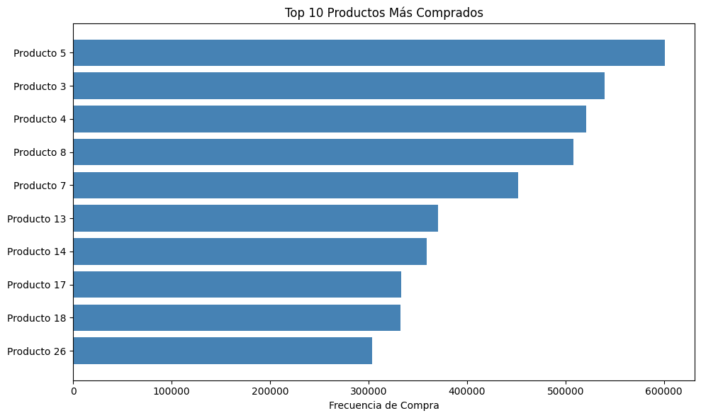

### Top 10 Clientes

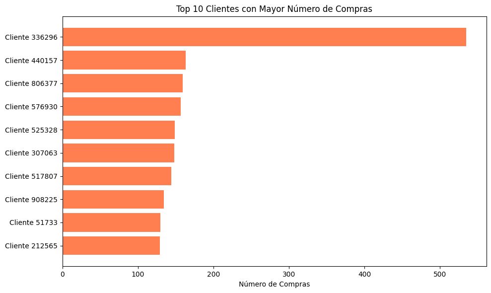

### Categorías Más Populares

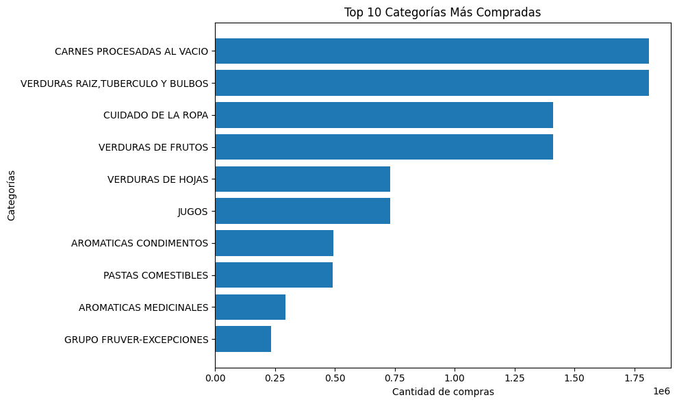

## 3. Visualizaciones Analíticas

📈 Visualizaciones Analíticas

### Serie de Tiempo - Ventas por Día

Top 5 picos más altos de ventas por día

- **2013-02-03** → 95644 unidades

- **2013-02-17** → 87282 unidades

- **2013-03-03** → 97246 unidades

- **2013-06-01** → 92298 unidades

- **2013-06-03** → 86810 unidades

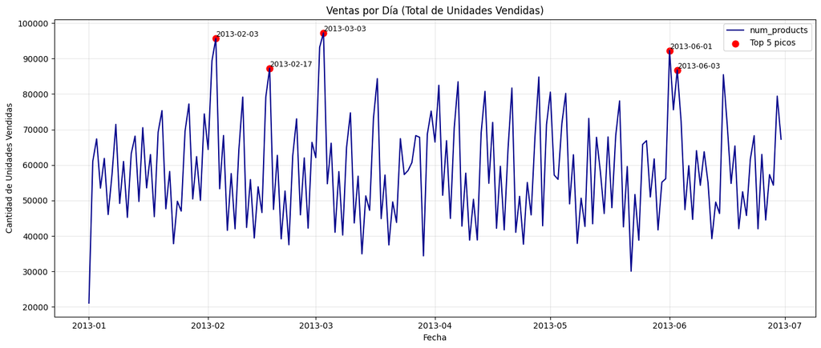

### Serie de Tiempo - Ventas por Semana

Top 3 semanas con más ventas

- **Semana que termina en 2013-01-28** → 486668 unidades

- **Semana que termina en 2013-02-25** → 469072 unidades

- **Semana que termina en 2013-04-01** → 466183 unidades

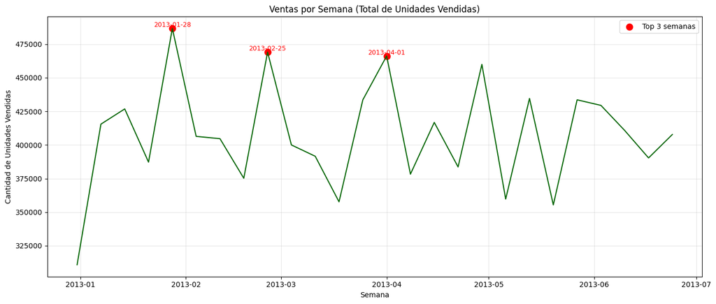

### Serie de Tiempo - Ventas por Mes

Mejor mes de ventas

**2013-03** → 1835406 unidades

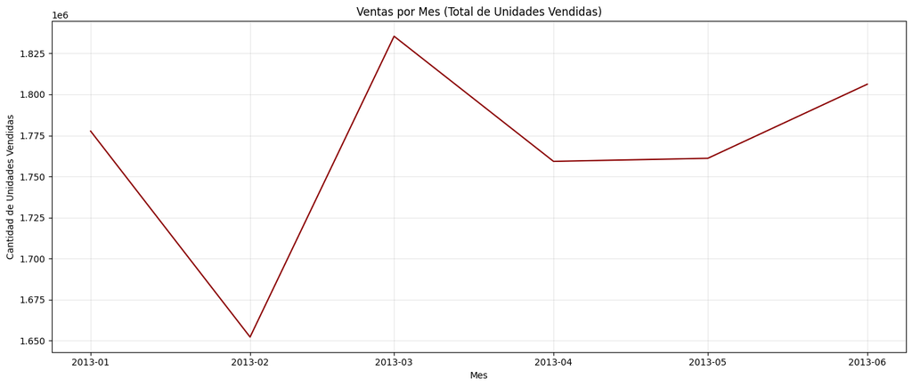

### Boxplot - Distribución de Productos por Cliente

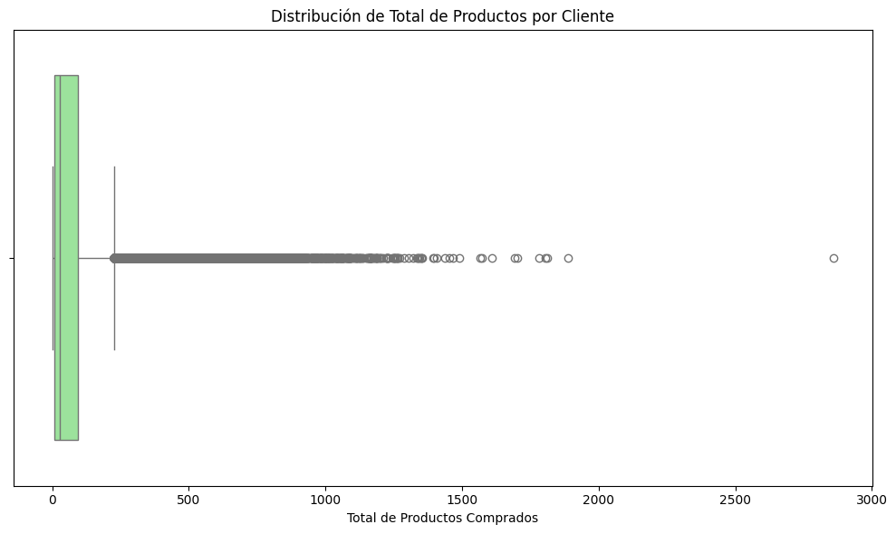

**Estadísticas:**

- Media: 80.74

- Mediana: 26.00

- Desviación Estándar: 131.99

- **Cantidad de outliers:** 13662

### Heatmap - Correlación entre Variables

Explicación de Variables Analizadas

**1. Total de compras (`total_compras`)**  
Cantidad total de transacciones realizadas por el cliente.

**2. Total de productos (`total_productos`)**  
Número total de unidades compradas por el cliente.

**3. Promedio de productos por compra (`promedio_productos`)**  
Cantidad promedio de productos adquiridos en cada transacción.

**4. Máximo de productos en una compra (`max_productos_transaccion`)**  
La compra individual más grande hecha por el cliente.

**5. Tiendas visitadas (`tiendas_visitadas`)**  
Número de tiendas distintas en las que el cliente ha comprado.  
Mide diversidad de comportamiento.

**6. Días entre compras (`dias_entre_compras`)**  
Promedio de días que pasan entre una compra y la siguiente.  
Indica frecuencia real de compra.

**7. Recencia (`recencia`)**  
Días desde la última compra hasta la fecha más reciente del dataset.  
Cuanto más bajo, más "activo" está el cliente.

**8. Antigüedad del cliente (`antiguedad_dias`)**  
Tiempo total entre la primera y la última compra del cliente.  
Mide cuánto lleva activo en el sistema.

Estas variables permiten entender patrón de compra, fidelidad, frecuencia, diversidad y actividad reciente del cliente, lo cual es clave para segmentación y modelos como RFM o clustering.

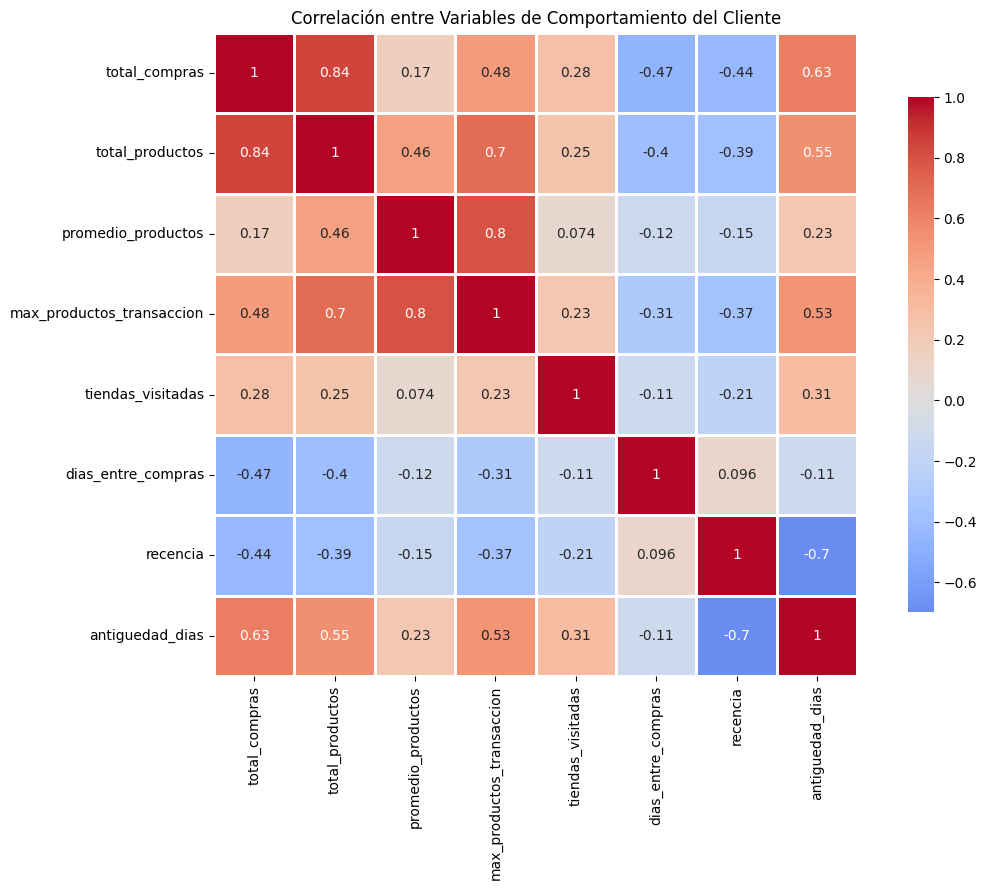

## 4. Análisis Temporal

📅 Análisis Temporal

### Ventas por Día de la Semana

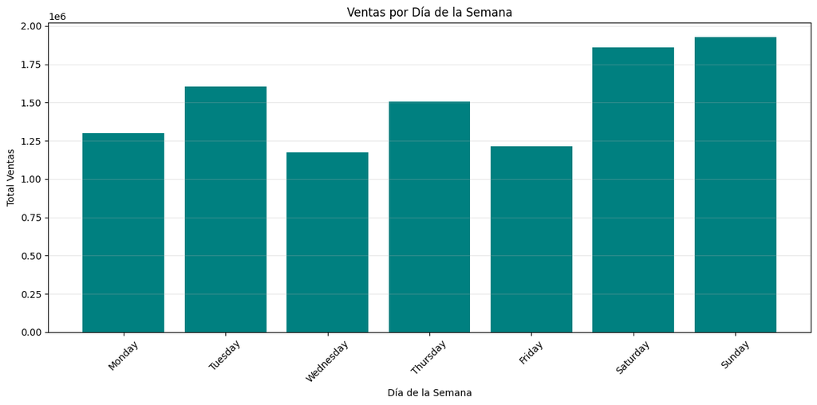

Hipótesis sobre las Ventas por Día de la Semana

Los días con mayor nivel de ventas son:

- **Sunday** → 1926651 unidades

- **Saturday** → 1860948 unidades

Hipótesis

Es posible que los días de fin de semana presenten más ventas debido a:

- Mayor disponibilidad de tiempo libre para comprar.

- Incremento en compras familiares o abastecimiento semanal.

- Promociones o actividades especiales típicas del fin de semana.

- Menor carga laboral o académica, lo que facilita la visita a tiendas.

Esta hipótesis podría confirmarse revisando datos adicionales como promociones, tráfico por tienda o comparaciones con semanas específicas del año.

### Ventas por Hora del Día

Notas sobre el análisis por hora del día

El gráfico muestra únicamente **un punto** porque en este dataset las transacciones **no contienen una hora específica**.  
Para poder agrupar ventas por hora del día, se necesitaría un campo de tiempo con formato **HH:MM:SS** o timestamps completos.

En este caso, todas las transacciones terminan concentradas en un único valor de `hora_dia`, por lo que el gráfico no representa variaciones reales a lo largo del día.

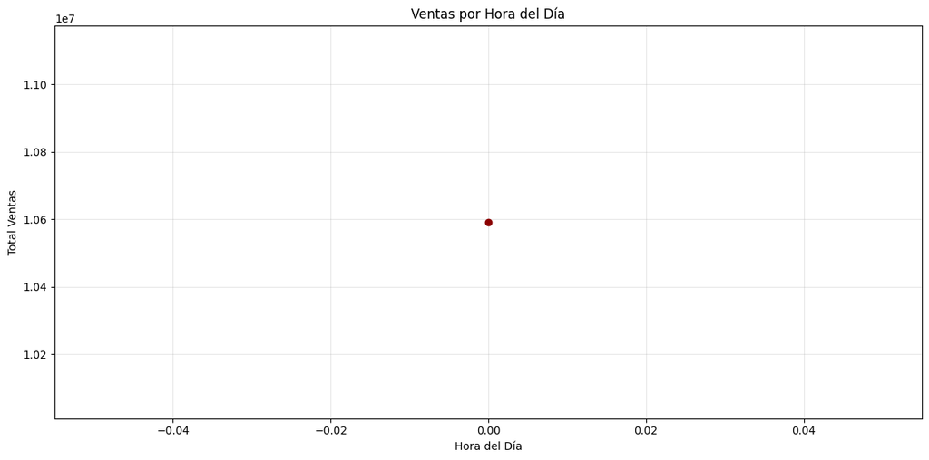

### Tendencias y Estacionalidad

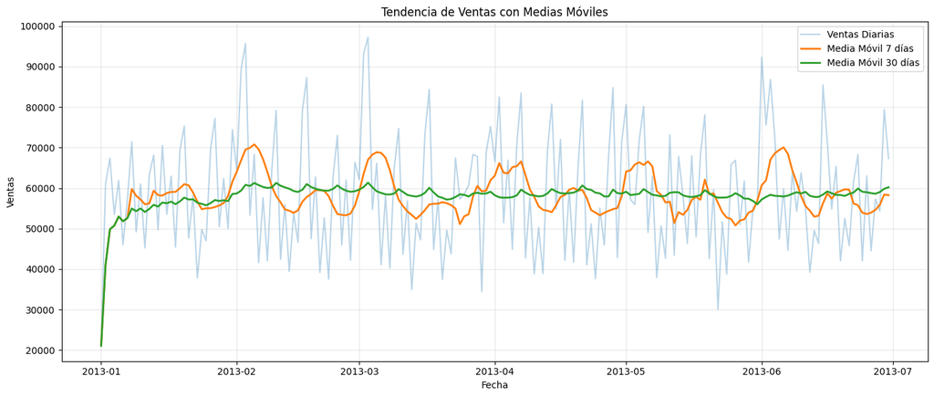

## 5. Análisis por Cliente

👥 Análisis por Cliente

### Distribución de Frecuencia de Compra

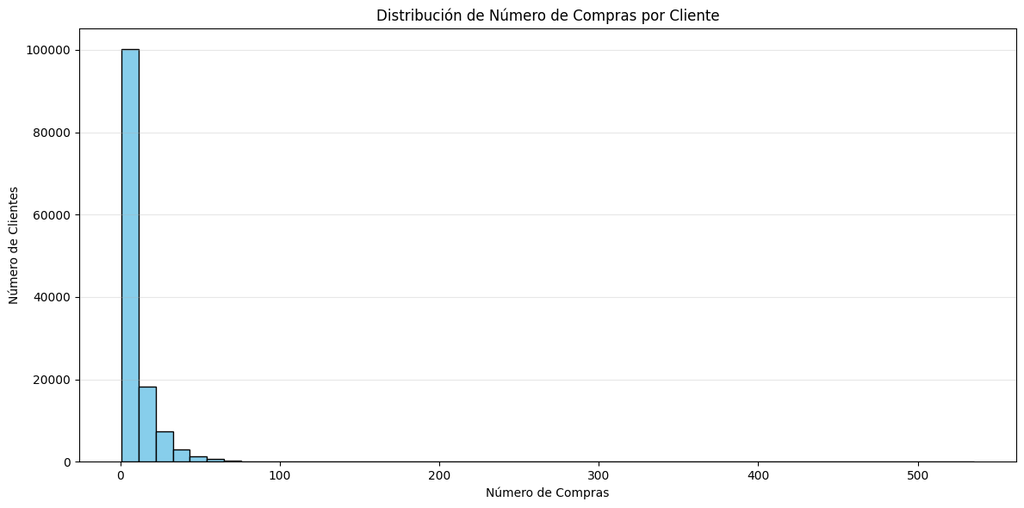

**Estadísticas de Frecuencia:**

- Compras promedio por cliente: 8.45

- Mediana de compras: 4.00

### Tiempo Promedio entre Compras

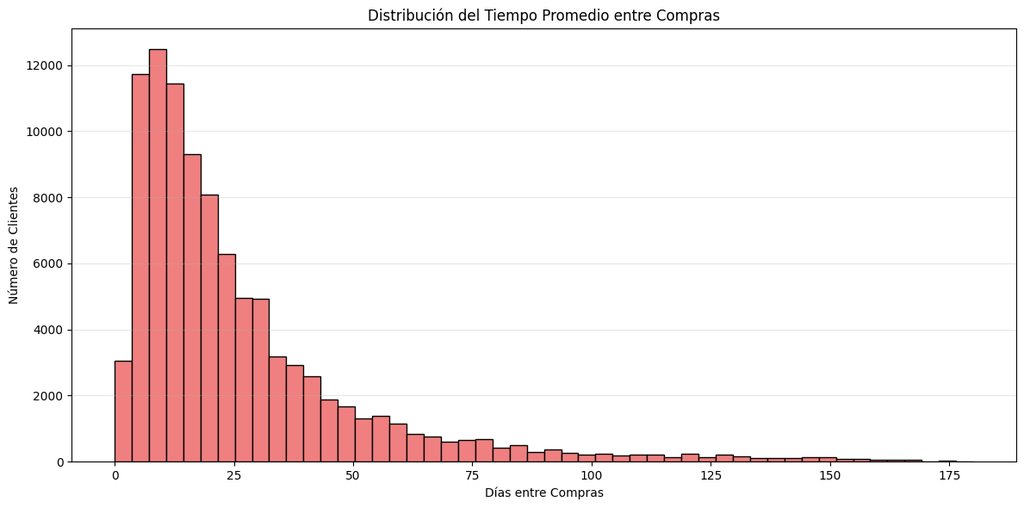

**Estadísticas de Intervalo:**

- Intervalo promedio: 26.39 días

- Mediana: 18.00 días

### Segmentación de Clientes

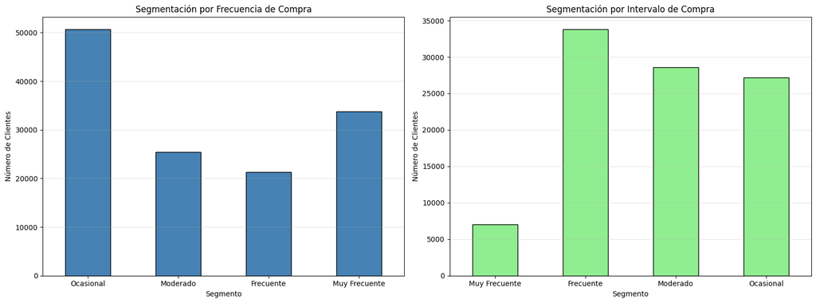

Frecuencia de Compra

- El segmento **más numeroso** es: **Ocasional** con **50695** clientes.

- El segmento **menos numeroso** es: **Frecuente** con **21290** clientes.

Intervalo Promedio entre Compras

- El segmento **más numeroso** es: **Frecuente** con **33819** clientes.

- El segmento **menos numeroso** es: **Muy Frecuente** con **7034** clientes.

Esto sugiere que, en términos de recurrencia, los clientes tienden a comportarse como **Frecuente**, mientras que el patrón **Muy Frecuente** es raro dentro de la base.

La comparación entre frecuencia y intervalo permite detectar inconsistencias:  
si un cliente compra pocas veces pero con intervalos cortos, podría representar **potencial de crecimiento**;  
si compra muchas veces pero intervalos largos, podría indicar **compras masivas pero poco recurrentes**.

## 6. Análisis Avanzado

🔬 Análisis Avanzado

### A. Segmentación de Clientes con K-Means

Segmentación de Clientes con K-Means

**Variables sugeridas:**

- Frecuencia de compra

- Número de productos distintos

- Volumen total

- Diversidad de categorías

📊 Resumen de Datos para Clustering

**Clientes para clustering:** 131186

📈 Estadísticas Descriptivas

|  | customer_id | frecuencia | dias_compra | productos_distintos | volumen_total | diversidad_categorias | recencia | ticket_promedio |
| --- | --- | --- | --- | --- | --- | --- | --- | --- |
| count | 131186.00 | 131186.00 | 131186.00 | 131186.00 | 131186.00 | 131186.00 | 131186.00 | 131186.00 |
| mean | 501565.30 | 116.42 | 8.43 | 31.67 | 2317.77 | 8.49 | 44.47 | 11.06 |
| std | 291880.94 | 190.17 | 11.13 | 33.01 | 5387.58 | 4.99 | 49.45 | 9.66 |
| min | 5.00 | 1.00 | 1.00 | 1.00 | 1.00 | 0.00 | 0.00 | 1.00 |
| 25% | 249359.75 | 10.00 | 1.00 | 6.00 | 42.00 | 4.00 | 7.00 | 4.00 |
| 50% | 499182.00 | 37.00 | 4.00 | 20.00 | 327.00 | 9.00 | 23.00 | 8.00 |
| 75% | 753451.75 | 137.00 | 11.00 | 45.00 | 2012.00 | 12.00 | 70.00 | 15.44 |
| max | 1009515.00 | 4073.00 | 180.00 | 356.00 | 188526.00 | 26.00 | 180.00 | 98.00 |

🔍 Métricas Clave

**Total de registros:**  
131,186

**Número de variables:**  
8

**Datos faltantes:**  
0

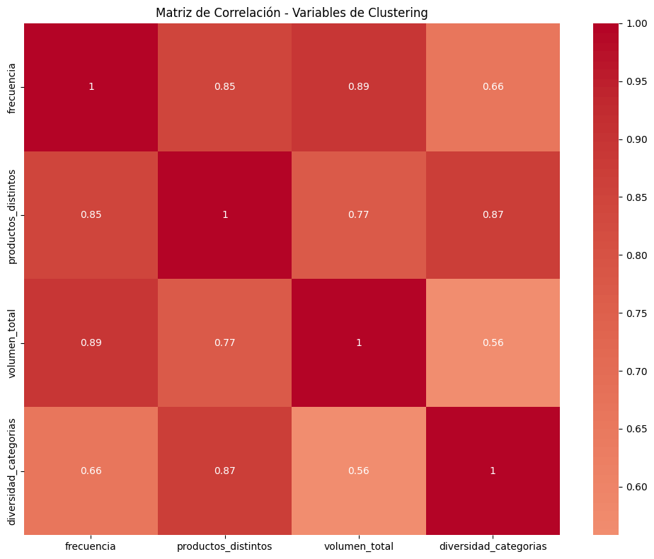

Análisis de Matriz de Correlación - Variables de Clustering

🔍 Hallazgos Principales

Correlaciones Fuertes (> 0.8)

- **frecuencia ↔ volumen_total**: 0.89  
  *Los clientes que compran más frecuentemente también compran mayor volumen*

- **frecuencia ↔ productos_distintos**: 0.85  
  *Mayor frecuencia está asociada con mayor variedad de productos*

⚠️ Consideraciones para Clustering

Multicolinealidad Detectada

- **frecuencia** y **volumen_total** están altamente correlacionadas (0.89)

- **productos_distintos** se correlaciona fuertemente con ambas variables anteriores

Recomendaciones

1. **Considerar reducción dimensional** con PCA

2. **Evaluar eliminar una variable** correlacionada

3. **Priorizar variables** que capturen dimensiones únicas del comportamiento

🎯 Variables Clave para Segmentación

| Variable | Utilidad | Observación |
| --- | --- | --- |
| **recencia** | Alta | Probablemente baja correlación (no mostrada) |
| **diversidad_categorías** | Media | Captura comportamiento exploratorio |
| **frecuencia** | Alta | Pero correlacionada con volumen |
| **ticket_promedio** | Media | Proporciona perspectiva de valor |

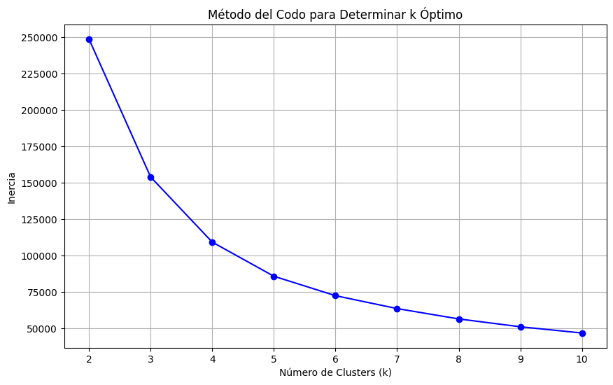

🎯 Análisis Combinado: Método del Codo y Silueta para K Óptimo

📊 Resultados de Ambos Métodos

Método del Codo

- **Rango óptimo identificado**: k = 4 a k = 6

- **Recomendación inicial**: k = 5 (balance ideal)

Método de Silueta

- **Puntuación para k = 4**: Aproximadamente 0.550

- **Puntuación para k = 6**: Aproximadamente 0.500

🔍 Interpretación Conjunta

Hallazgos Clave

- **k = 4** mantiene buena estructura (0.550) con mejor granularidad

- **k = 5** ofrece balance entre estructura (0.525) y utilidad práctica

- **k = 6** muestra disminución significativa en calidad (0.500)

⚖️ Recomendación Final

Opción 1: k = 4 (Recomendado)

- **Ventajas**: Buena puntuación de silueta (0.550) + Segmentación útil

- **Perfiles típicos**:

1. **Clientes Premium** - Alto valor, baja recencia

2. **Clientes Leales** - Frecuencia media, diversidad alta

3. **Clientes Ocasionales** - Baja frecuencia, recencia media

4. **Clientes Inactivos** - Alta recencia, necesitan reactivación

Opción 2: k = 5 (Alternativa)

- **Ventajas**: Balance práctico para acciones comerciales

- **Consideración**: Puntuación de silueta ligeramente inferior (0.525)

📊 Distribución de Clusters (k=4)

📈 Resumen de Distribución

- **Cluster 0**: 57070 clientes (43.5%)

- **Cluster 1**: 19191 clientes (14.6%)

- **Cluster 2**: 50850 clientes (38.8%)

- **Cluster 3**: 4075 clientes (3.1%)

**Total de clientes segmentados:** 131186

**Tamaño promedio por cluster:** 32796.5 clientes

**Cluster más grande:** 0 con 57070 clientes

**Cluster más pequeño:** 3 con 4075 clientes

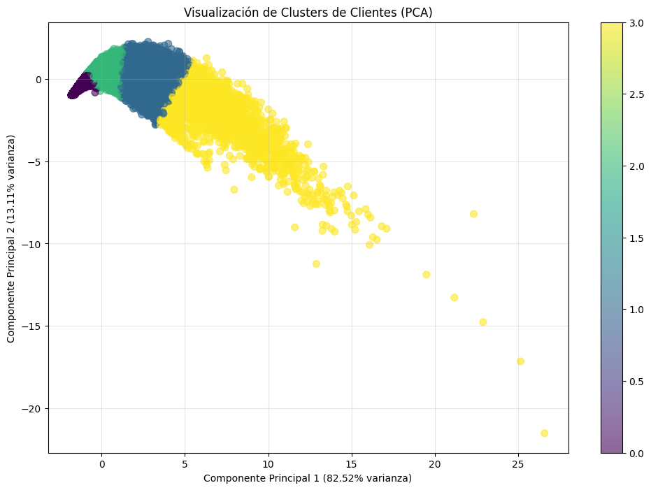

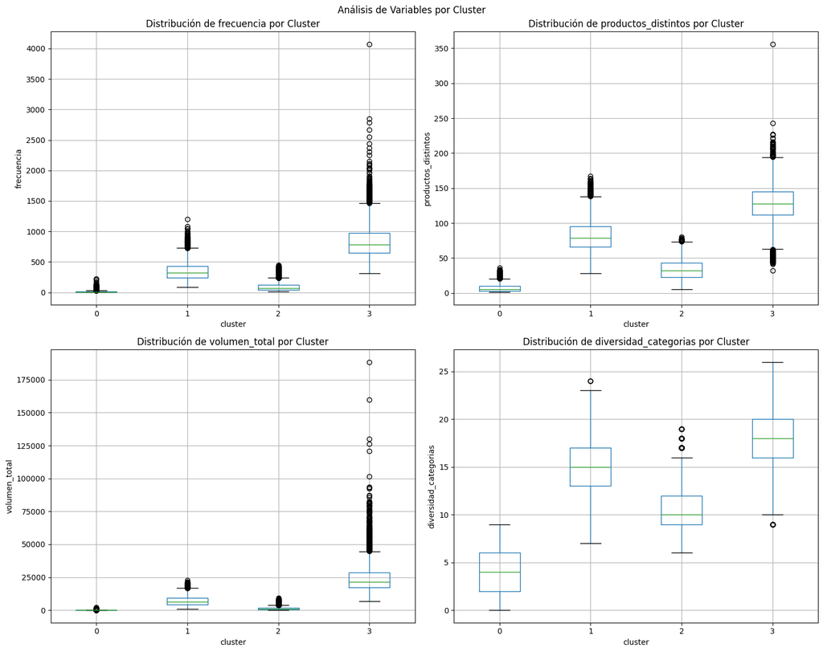

🎯 Análisis Detallado por Cluster

📊 Métricas Estadísticas por Cluster

Resumen de Indicadores Clave

| cluster | frecuencia mean | frecuencia std | frecuencia count | productos_distintos mean | productos_distintos std | volumen_total mean | volumen_total std | diversidad_categorias mean | diversidad_categorias std | recencia mean | recencia std | ticket_promedio mean | ticket_promedio std | customer_id count |
| --- | --- | --- | --- | --- | --- | --- | --- | --- | --- | --- | --- | --- | --- | --- |
| 0 | 10.96 | 10.50 | 57070 | 6.58 | 5.06 | 67.65 | 100.25 | 3.87 | 2.39 | 70.93 | 54.05 | 4.42 | 3.25 | 57070 |
| 1 | 347.19 | 141.74 | 19191 | 80.52 | 21.74 | 7081.26 | 3676.93 | 14.76 | 2.81 | 9.93 | 14.51 | 21.15 | 9.59 | 19191 |
| 2 | 89.83 | 64.20 | 50850 | 33.74 | 13.73 | 1235.57 | 1151.35 | 10.56 | 2.06 | 30.99 | 37.46 | 13.16 | 7.83 | 50850 |
| 3 | 838.37 | 282.92 | 4075 | 127.27 | 29.95 | 24901.55 | 12316.64 | 17.79 | 2.75 | 4.89 | 6.93 | 30.55 | 11.29 | 4075 |

👥 Perfiles de Clusters

|  | cluster | tamaño | porcentaje | frecuencia_promedio | productos_distintos_promedio | volumen_total_promedio | diversidad_categorias_promedio | recencia_promedio | ticket_promedio |
| --- | --- | --- | --- | --- | --- | --- | --- | --- | --- |
| 0 | 0.00 | 57070.00 | 43.50 | 10.96 | 6.58 | 67.65 | 3.87 | 70.93 | 4.42 |
| 1 | 1.00 | 19191.00 | 14.63 | 347.19 | 80.52 | 7081.26 | 14.76 | 9.93 | 21.15 |
| 2 | 2.00 | 50850.00 | 38.76 | 89.83 | 33.74 | 1235.57 | 10.56 | 30.99 | 13.16 |
| 3 | 3.00 | 4075.00 | 3.11 | 838.37 | 127.27 | 24901.55 | 17.79 | 4.89 | 30.55 |

🔍 Interpretación de Perfiles

Cluster 0 (43.5% de clientes)

- **Tamaño**: 57070 clientes

- **Frecuencia promedio**: 10.96 compras

- **Productos distintos**: 6.58

- **Volumen total**: 67.65 productos

- **Diversidad categorías**: 3.87

- **Recencia**: 70.93 días

Cluster 1 (14.6% de clientes)

- **Tamaño**: 19191 clientes

- **Frecuencia promedio**: 347.19 compras

- **Productos distintos**: 80.52

- **Volumen total**: 7081.26 productos

- **Diversidad categorías**: 14.76

- **Recencia**: 9.93 días

Cluster 2 (38.8% de clientes)

- **Tamaño**: 50850 clientes

- **Frecuencia promedio**: 89.83 compras

- **Productos distintos**: 33.74

- **Volumen total**: 1235.57 productos

- **Diversidad categorías**: 10.56

- **Recencia**: 30.99 días

Cluster 3 (3.1% de clientes)

- **Tamaño**: 4075 clientes

- **Frecuencia promedio**: 838.37 compras

- **Productos distintos**: 127.27

- **Volumen total**: 24901.55 productos

- **Diversidad categorías**: 17.79

- **Recencia**: 4.89 días

💡 Insights Generales

Patrones Identificados

1. **Clientes frecuentes**: Programas de fidelización

2. **Clientes recientes**: Campañas de seguimiento

3. **Clientes inactivos**: Estrategias de reactivación

4. **Clientes exploradores**: Recomendaciones personalizadas

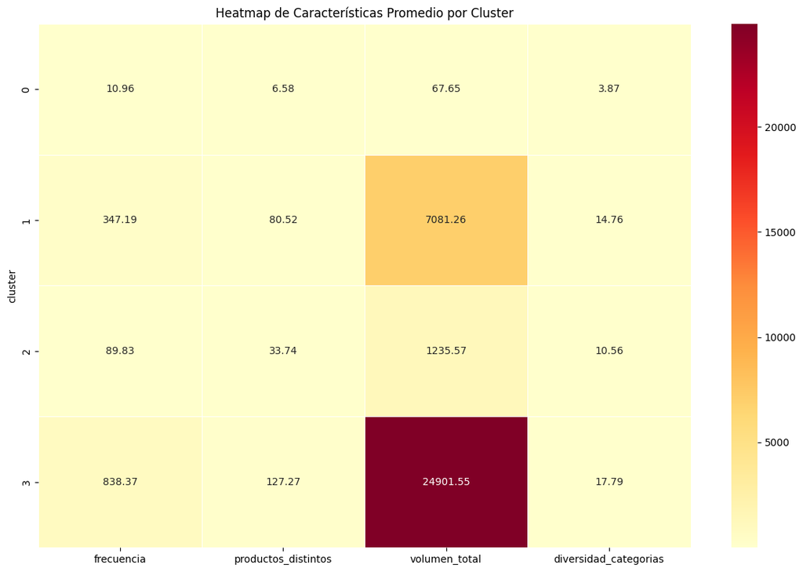

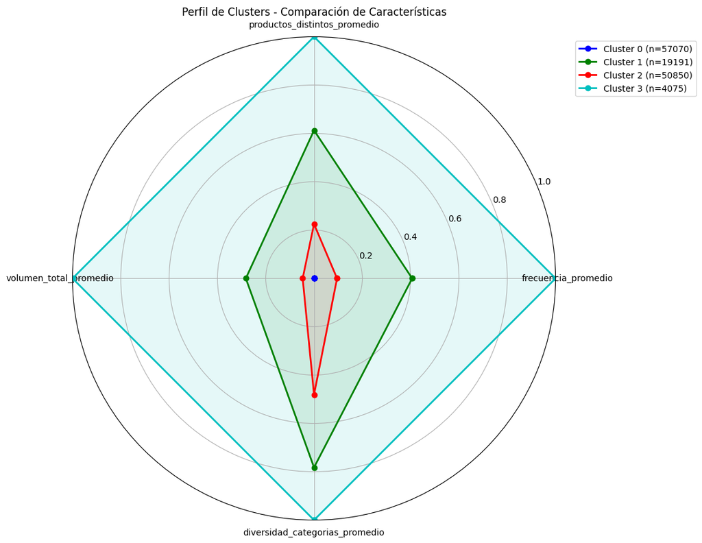

[output not shown]

[output cut: 21 more lines]

```
                ✓ Estrategia: Reactivación y engagement
                ✓ Acciones:
                   - Campañas de re-engagement
                   - Ofertas de bienvenida de vuelta
                   - Contenido educativo sobre productos
                   - Encuestas para entender abandono


                CLUSTER 3 - CLIENTES VALIOSOS
                ✓ Estrategia: Retención y fidelización
                ✓ Acciones:
                   - Programas de loyalty exclusivos
                   - Atención personalizada
                   - Ofertas premium y early access
                   - Encuestas de satisfacción regulares
```

[figure not shown]

### B. Sistema de Recomendación de Productos

🎯 Sistema de Recomendación de Productos

✅ **Reglas de asociación cargadas correctamente**

🧠 Sistema de Recomendación — Explicación Técnica

1️⃣ Recomendador Basado en Reglas de Asociación (FPGrowth)

🔍 ¿Cómo funciona?

1. Se crea una **cesta por cliente y fecha**, indicando qué productos aparecen juntos.

2. Se transforma en un formato **one-hot** donde 1 significa que el cliente compró un producto ese día.

3. Se ejecuta el algoritmo **FP-Growth**, que identifica conjuntos de productos que aparecen con frecuencia mínima del 1%.

4. A partir de estos conjuntos se generan **reglas de asociación** con métricas como:

   - **Soporte**: frecuencia total del conjunto.

   - **Confianza**: probabilidad de comprar B si se compró A.

   - **Lift**: qué tanto aumenta la probabilidad de B dado que ocurrió A (clave para detectar complementariedad real).

El recomendador de productos:

- recibe un **producto específico**,

- busca reglas donde ese producto es el **antecedente**,

- y recomienda los **consequents** con mayor *lift*.

🎯 Cuándo sirve

- Recomendaciones tipo **“productos que suelen comprarse juntos”**.

- Productos complementarios.

- Promociones en combo.

2️⃣ Recomendador Basado en Filtrado Colaborativo (Similitud entre Usuarios)

🔍 ¿Cómo funciona?

1. Se construye una matriz **cliente × producto** donde:

   - 1 = el cliente ha comprado ese producto al menos una vez.

2. Para un cliente dado, se calcula la **similitud del coseno** entre su vector y el del resto de clientes.

3. Se seleccionan los clientes más similares (vecinos).

4. Se calcula la **probabilidad promedio de compra** de cada producto entre esos vecinos.

5. Finalmente, se recomiendan productos que el cliente **no ha comprado todavía**.

🎯 Cuándo sirve

- Recomendaciones tipo **“clientes similares a vos compraron…”**.

- Descubrimiento de productos para usuarios con historial parcial.

- Enriquecer perfiles de clientes.

🧩 ¿Por qué usar ambos modelos?

Estos dos métodos resuelven **problemas distintos**:

- **Asociación de productos** detecta relación entre artículos, no entre personas.

- **Filtrado colaborativo** detecta relación entre clientes, no entre artículos.

Combinarlos mejora la calidad del sistema:

- Complementa productos específicos cuando el cliente ya compra algo (reglas).

- Sugiere nuevos productos basados en comportamiento global de usuarios (colaborativo).

✔️ Resultado

El sistema final puede:

- Recomendar productos adicionales basándose en **patrones reales de compra conjunta**.

- Generar recomendaciones personalizadas según **similitud entre usuarios**.

- Cubrir tanto recomendaciones **por producto** como **por cliente**.

```
mercury.Select
```

```
mercury.Numeric
```

```
mercury.Slider
```

Recomendaciones para Cliente 530.0

#### Funciones de Recomendación

Productos Recomendados:

[figure not shown]

## 7. Conclusiones

Conclusiones Generales y Aplicaciones Empresariales

1. Comportamiento del Cliente

El análisis de frecuencia, recencia e intervalos entre compras muestra una distribución heterogénea de los clientes. La mayoría pertenece a los segmentos ocasional o moderado, mientras que un grupo reducido concentra la mayor actividad. Los clientes con menor intervalo entre compras presentan mayor compromiso con la marca y mayor volumen total adquirido.

Aplicación empresarial: Permite orientar estrategias de retención y fidelización, identificando clientes en riesgo de abandono y aquellos con mayor potencial de valor a largo plazo.

2. Análisis de Productos y Reglas de Asociación

Las reglas obtenidas mediante el algoritmo fpgrowth revelan combinaciones de productos con fuerte relación de compra conjunta. La métrica lift identifica productos que, al ser adquiridos, elevan significativamente la probabilidad de compra de otros.

Aplicación empresarial: Facilita el diseño de promociones, paquetes de productos y estrategias de venta cruzada basadas en datos reales. Esto incrementa el ticket promedio y mejora la experiencia del cliente.

3. Recomendadores Implementados

a. Recomendador Colaborativo por Cliente

Basado en similitud entre clientes, sugiere artículos que consumidores con comportamientos similares han adquirido y que el cliente actual aún no compra.

Aplicación empresarial: Ideal para sistemas de sugerencias personalizadas, aumentando la probabilidad de recompra y fortaleciendo la lealtad.

b. Recomendador por Producto (basado en reglas de asociación)

Asocia productos complementarios a partir de frecuencias reales de co-ocurrencia. Prioriza combinaciones con mayor lift y confianza.

Aplicación empresarial: Útil para campañas de venta cruzada, recomendaciones en el punto de venta y optimización de catálogos en plataformas digitales.

4. Análisis Temporal

Las series temporales, junto con medias móviles de 7 y 30 días, permiten observar tendencias generales, variaciones estacionales y picos específicos de consumo. Este análisis suaviza la variabilidad diaria y muestra patrones de comportamiento más estables a mediano plazo.

Aplicación empresarial: Contribuye a la planificación de inventarios, asignación de recursos, proyección de demanda y toma de decisiones orientada a ciclos de consumo.

5. Segmentación de Clientes

La segmentación por frecuencia e intervalo de compra diferencia grupos de clientes según su comportamiento. Esto permite identificar clientes ocasionales, moderados, frecuentes y muy frecuentes, así como distinguir patrones basados en la regularidad de sus compras.

Aplicación empresarial: Permite ejecutar estrategias de marketing segmentado, enfocar campañas según tipo de cliente y desarrollar programas diferenciados de incentivos y retención.

Conclusión General

El análisis integrado de comportamiento del cliente, tendencias temporales, relaciones entre productos y modelos de recomendación ofrece una visión completa del funcionamiento del negocio. Estos resultados permiten optimizar decisiones relacionadas con inventarios, marketing, ventas y experiencia del cliente. Además, establecen la base para evolucionar hacia sistemas más avanzados de analítica predictiva y personalización automatizada.